# Student exercises

### Plotting the data

Another useful thing to do is to plot some of the values we have in the dataset. Visualising information as graphs 📊 can be very helpful!

One question we may want to ask is what the different modes of delivery by birth outcome are.

One option is to create a table with `Outcome` and `DeliveryMode`:

```r
table(metadata$Outcome, metadata$DeliveryMode)
```

```
          CesareanDelivery NormalSpontaneousVaginalDelivery
  Preterm               23                               26
  Term                  13                               34

          OperativeVaginalDelivery
  Preterm                        0
  Term                           3
```

We can see from the table there were more normal spontaneous vaginal deliveries in the term group compared to the preterm group (34 vs 26).

Instead of using tables, we could also show this information using a bar graph. Run the code below to generate a bar graph of the same data we have shown in the table above.

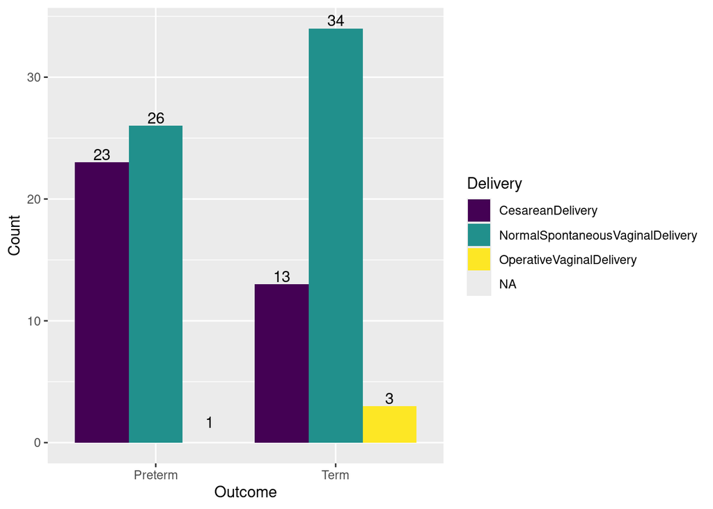

```r
ggplot(
  metadata,
  aes(x = Outcome, fill = DeliveryMode)) +
  geom_bar(position = "dodge") +
  geom_text(aes(label = after_stat(count)),
            stat = 'count', position = position_dodge(0.9), vjust = -0.2) +
  labs(x = "Outcome", y = "Count", fill = "Delivery") +
  scale_fill_viridis(discrete = TRUE)
```

🛑 **Checkpoint**

Have you been able to generate a graph using the code provided?

Take a look at the table and the graph showing delivery mode by preterm vs term delivery.

❓Which one is easier to interpret? Why?

❓Which group is more likely to deliver by C-section?

📝 **Challenge 3**

The bar graph has been produced using the package `ggplot`. It has a number of different options to format the graph. Using this as your guide, try to create the following plots:

1. For the delivery mode by birth outcome plot, change the y-axis from “Count” to “Number of deliveries” and plot this new graph?
2. Plot race by birth outcome (*Hint: there will be more than one part of the code you need to change for this*)

**Challenge 3 solution**

```r
ggplot(metadata, aes(x = Outcome, fill = DeliveryMode)) + geom_bar(position = "dodge") + geom_text(aes(label = after_stat(count)), stat = 'count', position = position_dodge(0.9), vjust = -0.2) + labs(x = "Outcome", y = "Number of deliveries", fill = "Delivery") + scale_fill_viridis(discrete = TRUE)
```

```r
ggplot(metadata, aes(x = Outcome, fill = Race)) + geom_bar(position = "dodge") + geom_text(aes(label = after_stat(count)), stat = 'count', position = position_dodge(0.9), vjust = -0.2) + labs(x = "Outcome", y = "Count", fill = "Race") + scale_fill_viridis(discrete = TRUE)
```

## The human microbiome

The human microbiome is an incredible community of trillions of microorganisms that live in and on our bodies. These tiny organisms include bacteria, viruses, fungi, and other microbes. They are found all over our body, including our skin, mouth, reproductive tract, and gut.

An adult human body is estimated to have around 37 trillion human cells.

❓Can you guess how many microbial cells may be present? The vast majority will be bacteria, but we also have protozoa, viruses, and fungi!

Because microbial cells are typically much smaller than human cells 🔬 they make up only 1%-3% of our body weight, but we it’s estimated that we each have somewhere between 10-100 trillion microbial cells!

More and more, scientists are discovering important links between the microbiome and our health. These bugs have important roles in helping us digest food, protect against harmful bacteria, modify our immune system, and even our mood!

Understanding the microbiome opens up exciting possibilities for improving our overall well-being and treating diseases.

In the study of microbiology and microbiomes, including the vaginal microbiome, researchers often analyse the composition of microbial communities by identifying and categorising the microorganisms present based on their taxonomic classification.

Taxonomic classification is a system to help understand the diversity and relationship between different microorganisms.

❓Can you name some of the levels of the taxonomic hierarchy

❓Which is the broadest of these?

❓Which is the most specific?

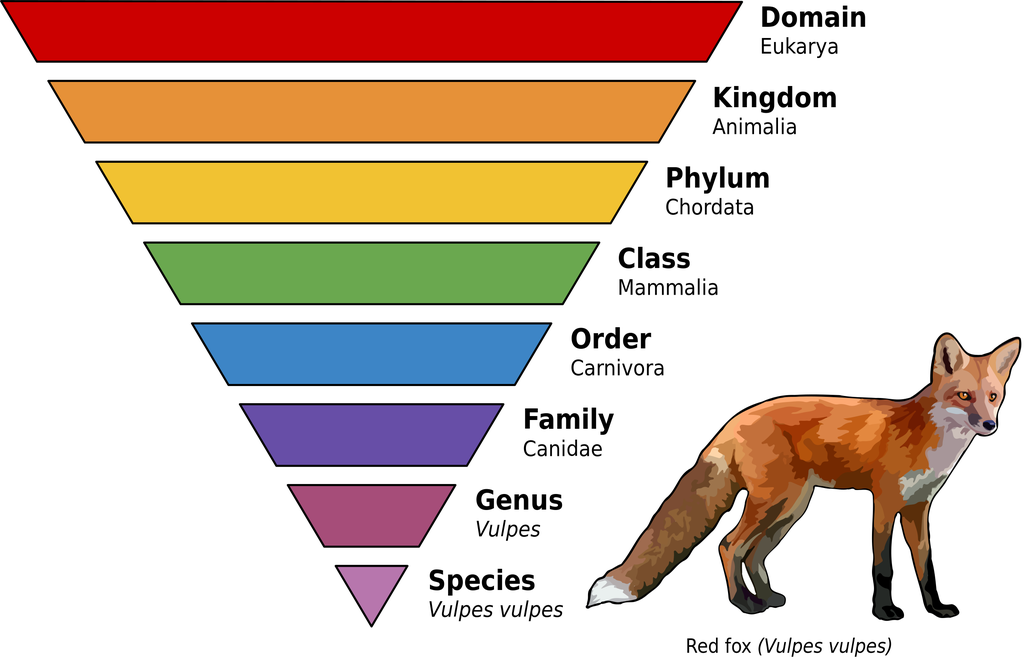

By Annina Breen - Own work This file was derived from: Rotfuchs.svg, CC BY-SA 4.0, https://commons.wikimedia.org/w/index.php?curid=40559754

### The vaginal microbiota in preterm birth

Researchers have been studying the potential link between the bacteria in the vaginal environment (vaginal microbiota) and preterm birth. In today’s session, we will be looking at bacteria in the vaginal environment based on their phyla. We are able to do this through advances in technology such as Next Generation Sequencing (NGS). By using NGS, we can sequence all kinds of DNA 🧬 (including DNA from bacteria). Using these genetic fingerprints, we can group them into phyla - sequences that are similar to each other and match known sequences from a particular phylum are grouped together.

The data that we are working with today has been sequenced from the vaginal microbiota using NGS.

## Diving into the microbiota data

Amazing! We have done some pre-processing of the bacterial DNA in the vaginal microbiota to group them into phyla.

*A note on using phyloseq to handle the microbiota data: `Phyloseq` is a package designed for the analysis and exploration of microbiota data. It helps us with importing, organizing, manipulating, and visualizing high-throughput sequencing data.*

👉 **Over to you!**

Because manipulating the data can be computationally intensive, we won’t be running `phyloseq` in today’s workshop as it may take a lot of time ⌛. To save us waiting, here’s a file we prepared earlier called `ps_phyla.csv`

In your own R script:

1. Import the `ps_phyla.csv` file, and assign it with the name `ps_phyla`
2. Look at the first few rows of data

```r
ps_phyla <- read.csv('ps_phyla.csv', header = TRUE, row.names = 1)
head(ps_phyla)
```

Look at the first few rows of data of the `ps_phyla` dataframe.

❓Do some of the columns look familiar to you?

❓Can you identify any new columns that have been added? What do they mean?

🛑 **Checkpoint**

Have you loaded the `ps_phyla` dataframe and can you see the first few rows?

This has combined the information we saw earlier from the metadata spreadsheet (e.g. birth outcome, delivery mode, BMI) with some new columns.

For each row, we can see that there is a sample ID, which has information on abundance and phylum. We can use this to plot the the abundance of a few of the most abundant phyla in the microbiome.

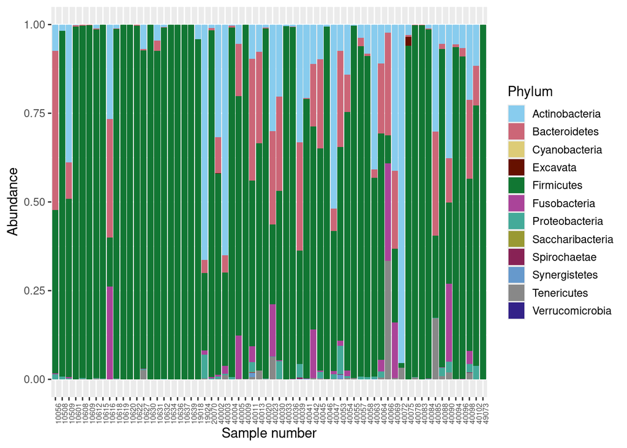

```r
safe_colorblind_palette <- c("#88CCEE", "#CC6677", "#DDCC77", "#661100", "#117733", "#AA4499",  "#44AA99", "#999933", "#882255",  "#6699CC", "#888888",  "#332288")

ggplot(ps_phyla, aes(x =factor(SubjectID), y =Abundance , fill = Phylum)) +
  geom_bar(stat = "identity", position = "fill") +
  theme(axis.text.x = element_text(angle = 90, hjust = 1, size = 6)) +
  guides(fill = guide_legend(reverse = FALSE, keywidth = 1, keyheight = 1, ncol = 1)) +
  ylab("Abundance") +
  xlab("Sample number")+
  scale_fill_manual(values = safe_colorblind_palette)
```

Let’s break down the graph above. On the x-axis we can see all of the sample numbers. Each bar represents one participant sample. The size of each colored section within the bar indicates the abundance (or amount) of that particular phylum in the sample.

🛑 **Checkpoint**

Can you generate the same graph of the abundance of each phylum in each sample?

Look at the graph with abundance of each phylum by sample.

❓Name some of the most abundant phyla we can see in the vaginal microbiota in these participants

❓What are some of the least abundant?

We will often compare our results against results from other researchers. In this case, we can look at the different abundances and top species, and see if it’s similar to what others have found. Let’s take a look at a figure from a research article below. Here, the four different bars each represent a group of participants - either healthy, or with a genital infection. Can you see how the phyla abundance seems to change between the groups?

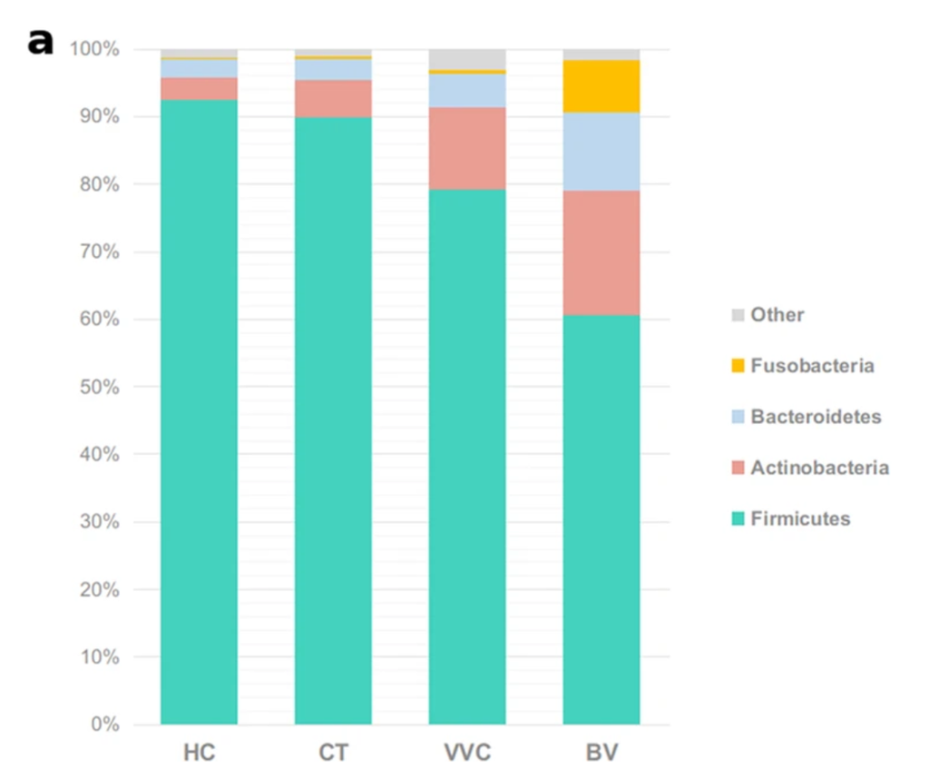

Stacked bar charts of taxonomy relative abundances at phylum for healthy (HC), C. trachomatis (CT), vulvo-vaginal candidiasis (VVC) and bacterial vaginosis (BV) positive subjects. Ceccarani, C., Foschi, C., Parolin, C. et al. (2019). 10.1038/s41598-019-50410-x

💡 In our dataset, we have information for each of these participants on whether they delivered term or preterm. Therefore, we could plot the graph by birth outcome.

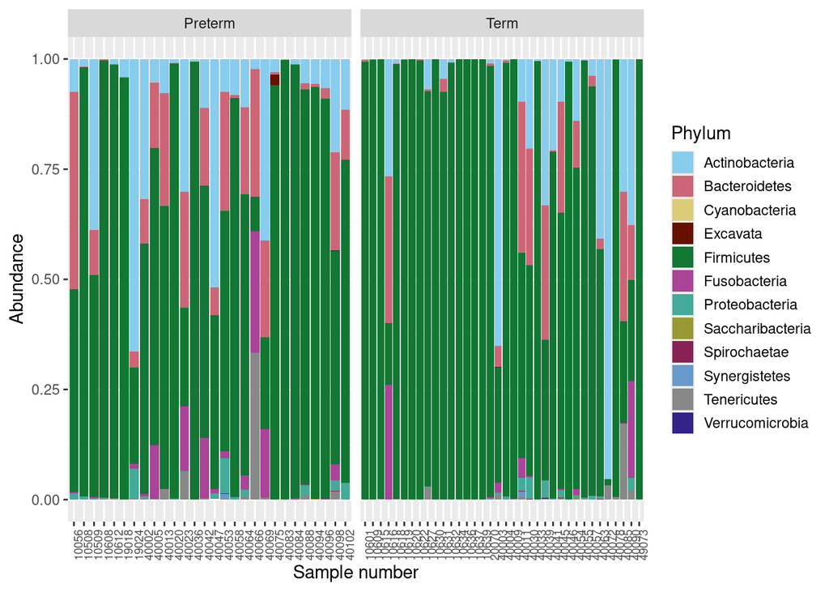

```r
ggplot(ps_phyla, aes(x =factor(SubjectID), y =Abundance , fill = Phylum)) +
  facet_wrap(~factor(Outcome), scales = 'free_x')+
  geom_bar(stat = "identity", position = "fill") +
  theme(axis.text.x = element_text(angle = 90, hjust = 1, size=7)) +
  guides(fill = guide_legend(reverse = FALSE, keywidth = 1, keyheight = 1, ncol = 1)) +
  ylab("Abundance") +
  xlab("Sample number") +
  scale_fill_manual(values = safe_colorblind_palette)
```

Now look at the graph with the abundance by phyla, and by birth outcome.

❓ Do you think there may be differences in the microbiota between women who deliver preterm vs term?

❓If so, how would you describe these differences?

**Congratulations for making it to the end of today’s workshop!** 🎉

Thank you for joining the session and we hope you enjoyed learning more about the world of bioinformatics and bacteria, and coding with R.